# From Quarto to Web

This document demonstrates the `nb2wb` converter with a Quarto (`.qmd`) source  
file. It covers the three pillars of technical writing: prose, mathematics, and  
code.

Here's a nice image for illustration.

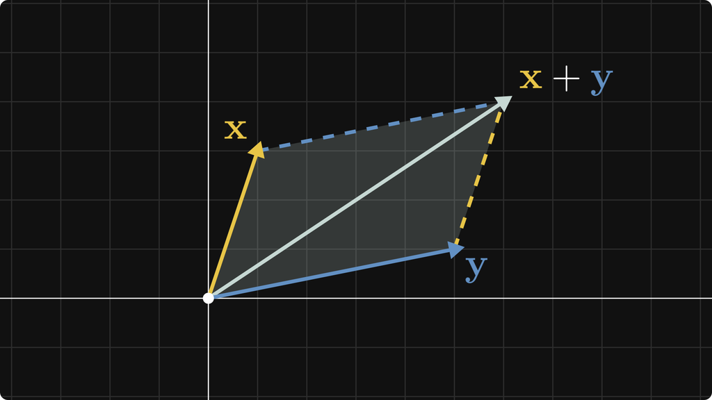

## 1 Inline LaTeX → Unicode

Inline expressions like *α* + *β* = *γ* or *E* = mc² are converted  
to Unicode so they render as plain readable text in Substack's editor.

Other examples: the golden ratio *ϕ* = (1+√5)/(2), and Euler's  
identity *e*<sup>*i**π*</sup> + 1 = 0.

## 2 Display Math → Image

Block equations are rendered to crisp PNG images.

The quadratic formula:

```latex
x = \frac{-b \pm \sqrt{b^2 - 4ac}}{2a} \label{eq:quadratic}
```

is rendered to

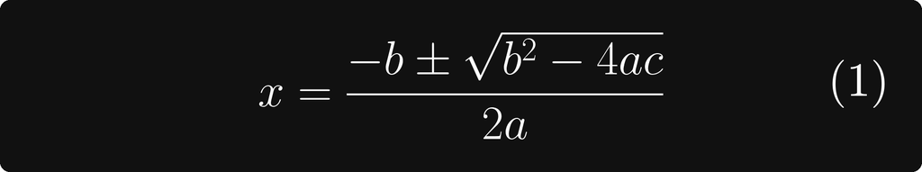

You can render the equation references as `\\eqref{eq:quadratic}`, which renders like this: (1) gives both roots of ax² + bx + *c* = 0 simultaneously.

You can also use colors that are defined in the preamble. Bayes' theorem:

```latex
P({\color{maizeCrayola} A} \mid {\color{blueGray} B}) = \frac{P({\color{blueGray} B} \mid {\color{maizeCrayola} A})\, P({\color{maizeCrayola} A})}{P({\color{blueGray} B})} \label{eq:bayes}
```

is rendered to

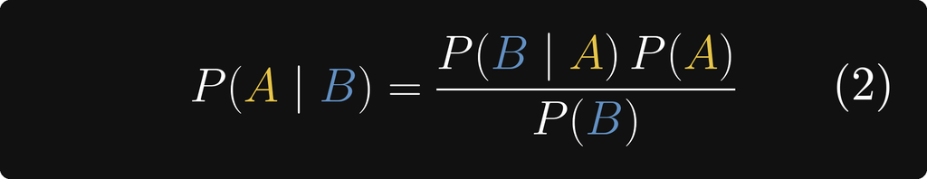

A matrix equation:

```latex
\mathbf{y} = \mathbf{X}\boldsymbol{\beta} + \boldsymbol{\varepsilon} \label{eq:mtx}
```

is rendered to

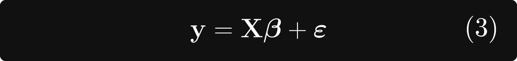

The Basel formula:

```latex
\sum_{n=1}^{\infty} \frac{1}{n^2} = \frac{\pi^2}{6}
```

is rendered to

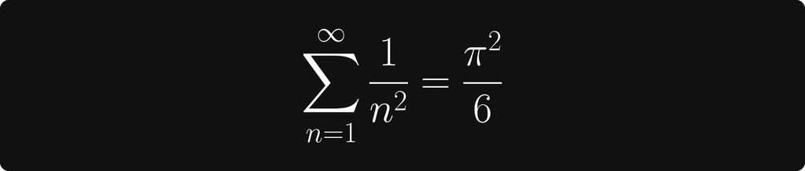

Now, a complex multi-line example. The Gaussian integral, derived by switching to polar coordinates:

```latex
\begin{align*}
I   &= \int_{-\infty}^{\infty} e^{-x^2}\,dx \\[4pt]
I^2 &= \int_{-\infty}^{\infty}\!\int_{-\infty}^{\infty} e^{-(x^2+y^2)}\,dx\,dy \\[4pt]
    &= \int_0^{2\pi}\!\int_0^{\infty} e^{-r^2}\,r\,dr\,d\theta \\[4pt]
    &= 2\pi \cdot \Bigl[-\tfrac{1}{2}e^{-r^2}\Bigr]_0^{\infty} \\[4pt]
    &= \pi \\[4pt]
\therefore\quad I &= \sqrt{\pi}
\end{align*}
```

is rendered to

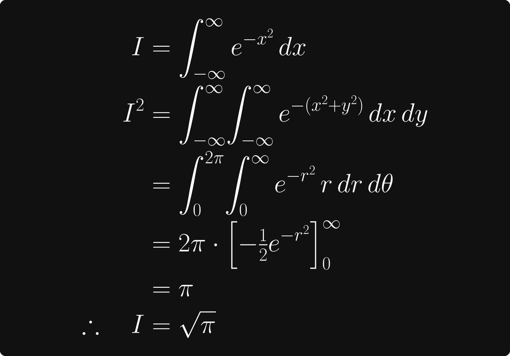

## 3 Code Blocks → Image

Code cells and their outputs are rendered as syntax-highlighted images,  
so formatting and colours are perfectly preserved.

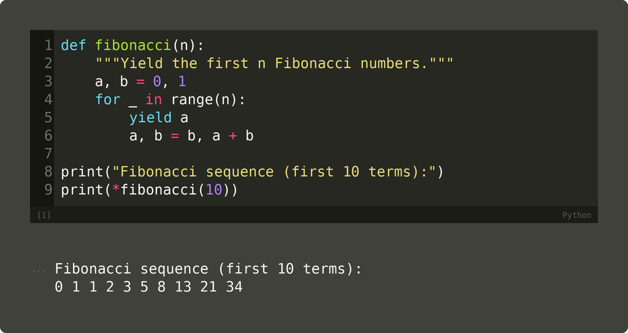

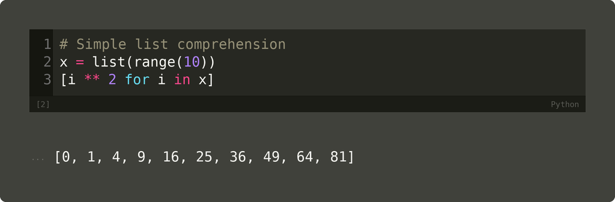

## 4 Mixed: equation in context

The softmax function maps a vector 𝐳 ∈ ℝᴷ to a  
probability distribution:

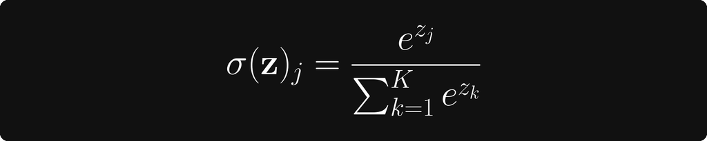

Here *j* = 1, …, *K* indexes the classes. Note that ∑ⱼ *σ*ⱼ = 1  
by construction.

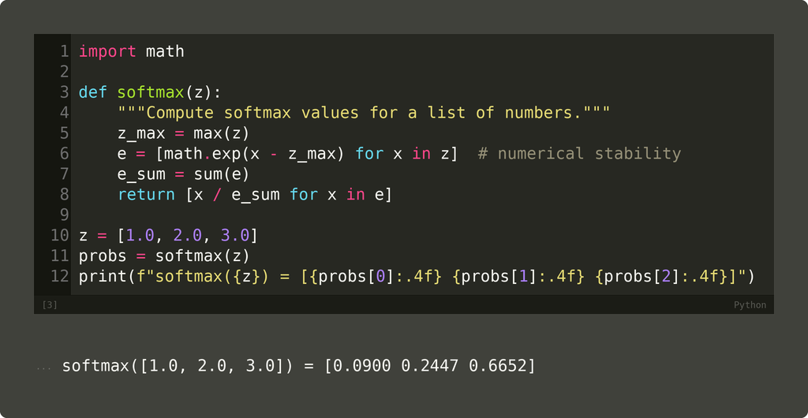

## 5 Figures

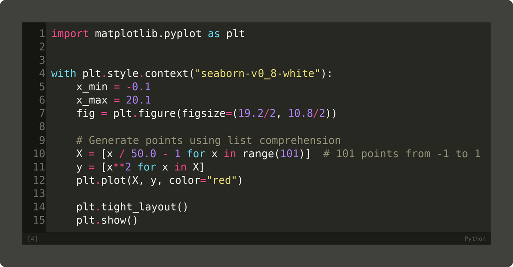

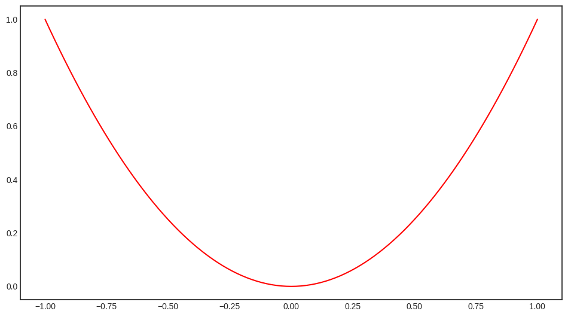

## 6 Cell Tags

Quarto cell options (`#|` lines) map to nb2wb cell tags:

| Quarto option | nb2wb tag | Effect |
| --- | --- | --- |
| `#\\| include: false` | `hide-cell` | Entire cell omitted (input + output) |
| `#\\| echo: false` | `hide-input` | Source code hidden; output shown |
| `#\\| output: false` | `hide-output` | Output hidden; source code shown |

The next cell uses `#| echo: false` — only its output is rendered.

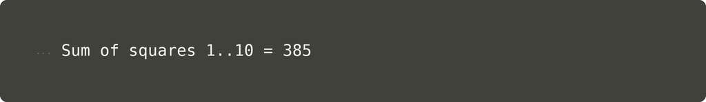

The next cell uses `#| output: false` — only its source code is rendered.

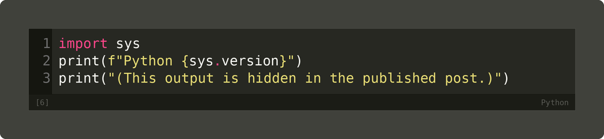

The preamble chunk at the top of this document uses the `{latex-preamble}`  
chunk type and is likewise invisible in the output.

Made with nb2wb